# SBA (Small Biz Admin.) Loan Approval Analysis & Prediction

## by Jungseok Lee

```python
from IPython.display import display, HTML
display(HTML("<style>.container { width:80% !important; }</style>"))

import warnings
warnings.filterwarnings('ignore')

import pandas as pd
import shap
import h2o
from h2o.estimators import H2OTargetEncoderEstimator
from h2o.estimators import H2OGradientBoostingEstimator
try:
    h2o.cluster().shutdown()
except:
    pass
```

```python
h2o.init(max_mem_size=8)
```

```
Checking whether there is an H2O instance running at http://localhost:54321..... not found.
Attempting to start a local H2O server...
; Java HotSpot(TM) 64-Bit Server VM (build 21.0.2+13-LTS-58, mixed mode, sharing)
  Starting server from C:\Users\wizdo\ml-spring-2024\Lib\site-packages\h2o\backend\bin\h2o.jar
  Ice root: C:\Users\wizdo\AppData\Local\Temp\tmpjnaynjql
  JVM stdout: C:\Users\wizdo\AppData\Local\Temp\tmpjnaynjql\h2o_wizdo_started_from_python.out
  JVM stderr: C:\Users\wizdo\AppData\Local\Temp\tmpjnaynjql\h2o_wizdo_started_from_python.err
  Server is running at http://127.0.0.1:54321
Connecting to H2O server at http://127.0.0.1:54321 ... successful.
Warning: Your H2O cluster version is (4 months and 8 days) old.  There may be a newer version available.
Please download and install the latest version from: https://h2o-release.s3.amazonaws.com/h2o/latest_stable.html
```

| H2O_cluster_uptime: | 02 secs |
| --- | --- |
| H2O_cluster_timezone: | America/Chicago |
| H2O_data_parsing_timezone: | UTC |
| H2O_cluster_version: | 3.44.0.3 |
| H2O_cluster_version_age: | 4 months and 8 days |
| H2O_cluster_name: | H2O_from_python_wizdo_u65zw3 |
| H2O_cluster_total_nodes: | 1 |
| H2O_cluster_free_memory: | 7.984 Gb |
| H2O_cluster_total_cores: | 0 |
| H2O_cluster_allowed_cores: | 0 |
| H2O_cluster_status: | locked, healthy |
| H2O_connection_url: | http://127.0.0.1:54321 |
| H2O_connection_proxy: | {"http": null, "https": null} |
| H2O_internal_security: | False |
| Python_version: | 3.10.11 final |

```python
data = h2o.import_file('./data/SBA_loans_project_2.csv')
```

```
Parse progress: |████████████████████████████████████████████████████████████████| (done) 100%
```

# Display a preview of the dataset

(check missing values and types of features)

```python
data.describe()
```

```
Rows:799356
Cols:20
```

|  | index | City | State | Zip | Bank | BankState | NAICS | NoEmp | NewExist | CreateJob | RetainedJob | FranchiseCode | UrbanRural | RevLineCr | LowDoc | DisbursementGross | BalanceGross | GrAppv | SBA_Appv | MIS_Status |
| --- | --- | --- | --- | --- | --- | --- | --- | --- | --- | --- | --- | --- | --- | --- | --- | --- | --- | --- | --- | --- |
| type | int | enum | enum | int | enum | enum | int | int | int | int | int | int | int | enum | enum | int | int | int | int | int |
| mins | 0.0 |  |  | 0.0 |  |  | 0.0 | 0.0 | 0.0 | 0.0 | 0.0 | 0.0 | 0.0 |  |  | 0.0 | 0.0 | 200.0 | 100.0 | 0.0 |
| mean | 399677.5 |  |  | 53800.14742367606 |  |  | 398464.7250036278 | 11.394357457753493 | 1.2804369640234123 | 8.483066368426583 | 10.845923468392051 | 2760.209923988812 | 0.7577237175926615 |  |  | 201304.19668583217 | 3.2413680512812815 | 192817.09646265252 | 149595.33292675603 | 0.1751472435310425 |
| maxs | 799355.0 |  |  | 99999.0 |  |  | 928120.0 | 9999.0 | 2.0 | 8800.0 | 9500.0 | 99999.0 | 2.0 |  |  | 11000000.0 | 996262.0 | 5472000.0 | 5472000.0 | 1.0 |
| sigma | 230754.34522669343 |  |  | 31185.719098605336 |  |  | 263323.9798013513 | 73.98731938246111 | 0.4518069755409015 | 237.7216771327966 | 238.15162043055298 | 12773.508715737113 | 0.6465583868789548 |  |  | 287436.21116562444 | 1525.7035072289236 | 283125.84660963324 | 228259.01277922525 | 0.3800932350734426 |
| zeros | 1 |  |  | 249 |  |  | 179717 | 5914 | 934 | 559592 | 391657 | 185609 | 287373 |  |  | 171 | 799343 | 0 | 0 | 659351 |
| missing | 0 | 25 | 12 | 0 | 1402 | 1408 | 0 | 0 | 114 | 0 | 0 | 0 | 0 | 4025 | 3616 | 0 | 0 | 0 | 0 | 0 |
| 0 | 0.0 | FORT LEE | NJ | 7024.0 | BNB HANA BANK NATL ASSOC | NJ | 425120.0 | 2.0 | 1.0 | 0.0 | 2.0 | 1.0 | 1.0 | Y | N | 10000.0 | 0.0 | 10000.0 | 5000.0 | 0.0 |
| 1 | 1.0 | WESTWEGO | LA | 70094.0 | JEDCO DEVELOPMENT CORPORATION | LA | 812331.0 | 62.0 | 1.0 | 6.0 | 0.0 | 1.0 | 1.0 | 0 | N | 353000.0 | 0.0 | 353000.0 | 353000.0 | 0.0 |
| 2 | 2.0 | DENVER | CO | 80209.0 | WELLS FARGO BANK NATL ASSOC | SD | 541611.0 | 4.0 | 1.0 | 1.0 | 4.0 | 1.0 | 1.0 | Y | N | 100000.0 | 0.0 | 100000.0 | 50000.0 | 0.0 |
| 3 | 3.0 | WRANGELL | AK | 99929.0 | FIRST BANK | AK | 446110.0 | 3.0 | 2.0 | 0.0 | 0.0 | 1.0 | 0.0 | N | Y | 75000.0 | 0.0 | 75000.0 | 67500.0 | 0.0 |
| 4 | 4.0 | MALVERN | AR | 72104.0 | CITICAPITAL SMALL BUS. FINANCE | TX | 0.0 | 1.0 | 2.0 | 0.0 | 0.0 | 52000.0 | 1.0 | 0 | Y | 45000.0 | 0.0 | 45000.0 | 36000.0 | 1.0 |
| 5 | 5.0 | HAMILTON SQUARE | NJ | 8619.0 | SUN NATIONAL BANK | NJ | 445110.0 | 3.0 | 1.0 | 2.0 | 3.0 | 1.0 | 1.0 | Y | N | 50000.0 | 0.0 | 50000.0 | 25000.0 | 0.0 |
| 6 | 6.0 | PHOENIX | AZ | 85040.0 | MUTUAL OF OMAHA BANK | AZ | 0.0 | 1.0 | 1.0 | 0.0 | 0.0 | 1.0 | 0.0 | N | N | 800000.0 | 0.0 | 800000.0 | 640000.0 | 0.0 |
| 7 | 7.0 | DENVER | CO | 80207.0 | JPMORGAN CHASE BANK NATL ASSOC | IL | 722211.0 | 11.0 | 1.0 | 0.0 | 11.0 | 0.0 | 1.0 | N | N | 35000.0 | 0.0 | 35000.0 | 17500.0 | 1.0 |
| 8 | 8.0 | CLEVELAND | OH | 44109.0 | U.S. BANK NATIONAL ASSOCIATION | OH | 445299.0 | 4.0 | 1.0 | 0.0 | 4.0 | 0.0 | 1.0 | Y | N | 37279.0 | 0.0 | 20000.0 | 10000.0 | 0.0 |
| 9 | 9.0 | ESCONDIDO | CA | 92025.0 | COMERICA BANK | TX | 621210.0 | 4.0 | 1.0 | 0.0 | 0.0 | 1.0 | 1.0 | 0 | N | 218800.0 | 0.0 | 233800.0 | 175350.0 | 1.0 |

```
[799356 rows x 20 columns]
```

# Clean up (Encode replace missing values)

```python
columns = ["City","State","Bank","BankState",
           "NewExist", "RevLineCr","LowDoc"]
num_col = data.columns_by_type(coltype="numeric")
enum_col = data.columns_by_type(coltype="categorical")
all_columns = data.columns

for col in columns:
    if all_columns.index(col)*1.0 in num_col:
        print("Fillna for numerical column:...", col)
        '''Alternative way '''
        data[data[col].isna(), col] = 0
    elif all_columns.index(col)*1.0 in enum_col:
        print("Fillna for categorical column:...", col)
        data[col] = data[col].ascharacter()
        data[data[col].isna(), col] = "Missing"
        data[col] = data[col].asfactor()
```

```
Fillna for categorical column:... City
Fillna for categorical column:... State
Fillna for categorical column:... Bank
Fillna for categorical column:... BankState
Fillna for numerical column:... NewExist
Fillna for categorical column:... RevLineCr
Fillna for categorical column:... LowDoc
```

```python
# missing values were filled with 0 or 'Missing'
```

# Split dataset to Train/Valid/Test

```python
train,valid,test = data.split_frame(ratios=[.6, .2], seed=1234)
```

# Change to categorical variables for feature engineering

```python
cat_columns = ["City","State","Bank","BankState", "UrbanRural", "FranchiseCode",
               "NewExist", "RevLineCr","LowDoc", "Zip", "NAICS"]
encoded_columns = cat_columns
response = "MIS_Status"

train[encoded_columns+[response]] = train[encoded_columns+[response]].asfactor()
valid[encoded_columns+[response]] = valid[encoded_columns+[response]].asfactor()
test[encoded_columns+[response]] = test[encoded_columns+[response]].asfactor()
```

# Add engineered features

(Excluded some features that didn't improve the model performance)

```python
train_0 = train
```

```python
import numpy as np

column_to_bin = col = "BalanceGross"
col_np_array = np.array(train_0[column_to_bin].as_data_frame(use_pandas=True)[column_to_bin].values, dtype=np.int64) # Convert single column to numpy array

counts, breaks = np.histogram(col_np_array, bins=5)
```

```
converting H2O frame to pandas dataframe using single-thread.  For faster conversion using multi-thread, install datatable (for Python 3.9 or lower), or polars and pyarrow (for Python 3.10 or above).
```

```python
min_val = min(col_np_array)-1                              # Establish min and max values
max_val = max(col_np_array)+1

new_b = [int(min_val)]                                      # Redefine breaks such that each bucket has enough support
for i in range(4):
    if counts[i] > 1000 and counts[i+1] > 1000:
        new_b.append(int(breaks[i+1]))
new_b.append(int(max_val))

names = [col + '_' + str(x) for x in range(len(new_b)-1)]  # Generate names for buckets, these will be categorical names
```

```python
train[col+"_cut"] = train[col].cut(breaks=new_b, labels=names)
```

```python
def cut_column(col_np_array, train, valid, test, col):

    counts, breaks = np.histogram(col_np_array, bins=100)   # Generate counts and breaks for our histogram
    min_val = min(col_np_array)-1                              # Establish min and max values
    max_val = max(col_np_array)+1

    new_b = [int(min_val)]                                      # Redefine breaks such that each bucket has enough support
    for i in range(99):
        if counts[i] > 1000 and counts[i+1] > 1000:
            new_b.append(int(breaks[i+1]))
    new_b.append(int(max_val))

    names = [col + '_' + str(x) for x in range(len(new_b)-1)]  # Generate names for buckets, these will be categorical names

    train[col+"_cut"] = train[col].cut(breaks=new_b, labels=names)
    valid[col+"_cut"] = valid[col].cut(breaks=new_b, labels=names)
    test[col+"_cut"] = test[col].cut(breaks=new_b, labels=names)
```

```python
def add_features(train, valid, test):

    '''
    Helper function to add binning and interaction features to the dataset
    '''

    # Transform numerical columns to categorical via binning
    for column_to_bin in [#"NoEmp",
                          #"CreateJob",
                          "RetainedJob",
                          #"DisbursementGross",
                          "BalanceGross",
                          #"GrAppv",
                          "SBA_Appv"]:
        print("Binning Column: {}".format(column_to_bin))
        col_np_array = np.array(train[column_to_bin].as_data_frame(use_pandas=True)[column_to_bin].values, dtype=np.int64) # Convert single column to numpy array
        cut_column(col_np_array, train, valid, test, column_to_bin)

    #Add interaction columns for a subset of columns
    interaction_cols1 = [#"NoEmp_cut",
                         #"City",
                         "State",
                         "Bank",
                         "BankState",
                         "NAICS",
                         "NewExist",
                         #"CreateJob_cut",
                         "RetainedJob_cut",
                         "UrbanRural",
                         "RevLineCr",
                         "LowDoc",
                         "FranchiseCode",
                         #"DisbursementGross_cut",
                         "BalanceGross_cut",
                         #"GrAppv_cut",
                         "SBA_Appv_cut"]

    train_cols = train.interaction(factors=interaction_cols1,    #Generate pairwise columns
                                   pairwise=True,
                                   max_factors=1000,
                                   min_occurrence=100,
                                   destination_frame="itrain")
    valid_cols = valid.interaction(factors=interaction_cols1,
                                   pairwise=True,
                                   max_factors=1000,
                                   min_occurrence=100,
                                   destination_frame="ivalid")
    test_cols = test.interaction(factors=interaction_cols1,
                                   pairwise=True,
                                   max_factors=1000,
                                   min_occurrence=100,
                                   destination_frame="itest")

    train = train.cbind(train_cols)                              #Append pairwise columns to H2OFrames
    valid = valid.cbind(valid_cols)
    test = test.cbind(test_cols)

    print("All columns added via interaction",train_cols.columns)

    return train, valid, test
```

```python
train_f, valid_f, test_f = add_features(train, valid, test)
```

```
Binning Column: RetainedJob
```

```
converting H2O frame to pandas dataframe using single-thread.  For faster conversion using multi-thread, install datatable (for Python 3.9 or lower), or polars and pyarrow (for Python 3.10 or above).
```

```
Binning Column: BalanceGross
```

```
converting H2O frame to pandas dataframe using single-thread.  For faster conversion using multi-thread, install datatable (for Python 3.9 or lower), or polars and pyarrow (for Python 3.10 or above).
```

```
Binning Column: SBA_Appv
```

```
converting H2O frame to pandas dataframe using single-thread.  For faster conversion using multi-thread, install datatable (for Python 3.9 or lower), or polars and pyarrow (for Python 3.10 or above).
```

```
Interactions progress: |█████████████████████████████████████████████████████████| (done) 100%
Interactions progress: |█████████████████████████████████████████████████████████| (done) 100%
Interactions progress: |█████████████████████████████████████████████████████████| (done) 100%
All columns added via interaction ['State_Bank', 'State_BankState', 'State_NAICS', 'State_NewExist', 'State_RetainedJob_cut', 'State_UrbanRural', 'State_RevLineCr', 'State_LowDoc', 'State_FranchiseCode', 'State_BalanceGross_cut', 'State_SBA_Appv_cut', 'Bank_BankState', 'Bank_NAICS', 'Bank_NewExist',…
```

# Re-define cat_columns for target encoding

(Exclude 4 features that are not suitable)

```python
cat_columns = ["City","State","Bank","BankState", "FranchiseCode",
               "RevLineCr","LowDoc"] #"Zip", "NAICS", "UrbanRural","NewExist"
```

```python
encoder_te = H2OTargetEncoderEstimator(#fold_column=fold_column,
                                        data_leakage_handling=None,
                                        blending=True,
                                        inflection_point=15,
                                        smoothing=10,
                                        seed=1234)

encoder_te.train(x=cat_columns,
                 y=response,
                 training_frame=train_f)
```

```
targetencoder Model Build progress: |████████████████████████████████████████████| (done) 100%
```

```
Model Details
=============
H2OTargetEncoderEstimator : TargetEncoder
Model Key: TargetEncoder_model_python_1714353241713_1
```

Target Encoder model summary: Summary for target encoder model

| original_names | encoded_column_names |
| --- | --- |
| City | City_te |
| State | State_te |
| Bank | Bank_te |
| BankState | BankState_te |
| FranchiseCode | FranchiseCode_te |
| RevLineCr | RevLineCr_te |
| LowDoc | LowDoc_te |

```
[tips]
Use `model.explain()` to inspect the model.
--
Use `h2o.display.toggle_user_tips()` to switch on/off this section.
```

# Save target encoder path

```python
encoder_path = h2o.save_model(model=encoder_te, path="./artifacts", force=True)
```

```python
encoder_path
```

```
'C:\\Users\\wizdo\\Downloads\\artifacts\\TargetEncoder_model_python_1714353241713_1'
```

# Add the features created through target encoding.

```python
train_te = encoder_te.transform(frame=train_f, as_training=True)
valid_te = encoder_te.transform(frame=valid_f, as_training=False)
test_te = encoder_te.transform(frame=test_f, as_training=False)
```

# Prepare for model training and tuning.

```python
predictors = train_te.columns
```

```python
for col in cat_columns+[response]:
    predictors.remove(col)
```

# Remove "index" column for training

```python
predictors.remove("index")
```

# Model traing and tuning (GBM(H2O))

```python
best_auc = 0
best_nfolds = 0
best_ntrees = 0
best_max_depth = 0
best_stopping_rounds = 0
best_stopping_metric = []
best_model = None

for nfolds in [3, 4, 5]:
    for ntrees in [30, 50, 80, 100, 130]:
        for stopping_rounds in [3, 5]:
            for max_depth in [3, 5]:
                for stopping_metric in ["MAE"]:
                    model = H2OGradientBoostingEstimator(nfolds = nfolds,
                                                         ntrees = ntrees,
                                                         max_depth = max_depth,
                                                         stopping_rounds = stopping_rounds,
                                                         stopping_metric = stopping_metric,
                                                         seed=1234,
                                                         keep_cross_validation_predictions = False)
                    model.train(y=response, x=predictors, training_frame=train_te, validation_frame=valid_te)

                    auc = model.model_performance(valid=True).auc()
                    if auc > best_auc:
                        best_auc = auc
                        best_nfolds = nfolds
                        best_ntrees = ntrees
                        best_max_depth = max_depth
                        best_stopping_rounds = stopping_rounds
                        best_stopping_metric = stopping_metric
                        best_model = model
                        print("Better Model found. Trained H2OGBM with (auc, nfolds, ntrees, stopping_rounds, stopping_metric):(", \
                              auc, nfolds, ntrees, max_depth, stopping_rounds, stopping_metric,")")

print("Best model AUC(on valid dataset):", best_auc)
print("Best model AUC(on test dataset):", best_model.model_performance(test_data=test_te).auc())
```

```
gbm Model Build progress: |██████████████████████████████████████████████████████| (done) 100%
Better Model found. Trained H2OGBM with (auc, nfolds, ntrees, stopping_rounds, stopping_metric):( 0.8101122794405948 3 30 3 3 MAE )
gbm Model Build progress: |██████████████████████████████████████████████████████| (done) 100%
Better Model found. Trained H2OGBM with (auc, nfolds, ntrees, stopping_rounds, stopping_metric):( 0.817585119510624 3 30 5 3 MAE )
gbm Model Build progress: |██████████████████████████████████████████████████████| (done) 100%
gbm Model Build progress: |██████████████████████████████████████████████████████| (done) 100%
gbm Model Build progress: |██████████████████████████████████████████████████████| (done) 100%
gbm Model Build progress: |██████████████████████████████████████████████████████| (done) 100%
Better Model found. Trained H2OGBM with (auc, nfolds, ntrees, stopping_rounds, stopping_metric):( 0.8225207586854927 3 50 5 3 MAE )
gbm Model Build progress: |██████████████████████████████████████████████████████| (done) 100%
gbm Model Build progress: |██████████████████████████████████████████████████████| (done) 100%
gbm Model Build progress: |██████████████████████████████████████████████████████| (done) 100%
gbm Model Build progress: |██████████████████████████████████████████████████████| (done) 100%
Better Model found. Trained H2OGBM with (auc, nfolds, ntrees, stopping_rounds, stopping_metric):( 0.825371561631955 3 80 5 3 MAE )
gbm Model Build progress: |██████████████████████████████████████████████████████| (done) 100%
gbm Model Build progress: |██████████████████████████████████████████████████████| (done) 100%
gbm Model Build progress: |██████████████████████████████████████████████████████| (done) 100%
gbm Model Build progress: |██████████████████████████████████████████████████████| (done) 100%
Better Model found. Trained H2OGBM with (auc, nfolds, ntrees, stopping_rounds, stopping_metric):( 0.8260393864349381 3 100 5 3 MAE )
gbm Model Build progress: |██████████████████████████████████████████████████████| (done) 100%
gbm Model Build progress: |██████████████████████████████████████████████████████| (done) 100%
gbm Model Build progress: |██████████████████████████████████████████████████████| (done) 100%
gbm Model Build progress: |██████████████████████████████████████████████████████| (done) 100%
Better Model found. Trained H2OGBM with (auc, nfolds, ntrees, stopping_rounds, stopping_metric):( 0.8260729441934694 3 130 5 3 MAE )
gbm Model Build progress: |██████████████████████████████████████████████████████| (done) 100%
gbm Model Build progress: |██████████████████████████████████████████████████████| (done) 100%
gbm Model Build progress: |██████████████████████████████████████████████████████| (done) 100%
gbm Model Build progress: |██████████████████████████████████████████████████████| (done) 100%
gbm Model Build progress: |██████████████████████████████████████████████████████| (done) 100%
gbm Model Build progress: |██████████████████████████████████████████████████████| (done) 100%
gbm Model Build progress: |██████████████████████████████████████████████████████| (done) 100%
gbm Model Build progress: |██████████████████████████████████████████████████████| (done) 100%
gbm Model Build progress: |██████████████████████████████████████████████████████| (done) 100%
gbm Model Build progress: |██████████████████████████████████████████████████████| (done) 100%
gbm Model Build progress: |██████████████████████████████████████████████████████| (done) 100%
gbm Model Build progress: |██████████████████████████████████████████████████████| (done) 100%
gbm Model Build progress: |██████████████████████████████████████████████████████| (done) 100%
gbm Model Build progress: |██████████████████████████████████████████████████████| (done) 100%
gbm Model Build progress: |██████████████████████████████████████████████████████| (done) 100%
gbm Model Build progress: |██████████████████████████████████████████████████████| (done) 100%
```

[output cut: 13 more lines]

[output not shown]

As a result of 60 combinations, the auc value of the valid data was the highest(0.82607) under the condition (nfolds = 3, ntrees = 130, max_depth = 5, stopping_rounds = 3, stopping_metric = MAE), so this model was set as the best model.

# Final metrics using Test dataset

(Threshold calculation and Report final AUC metric and confusion matrix on the Test dataset)

```python
best_model.model_performance(test_data=test_te)
```

```
ModelMetricsBinomial: gbm
** Reported on test data. **

MSE: 0.11013973593898531
RMSE: 0.33187307203053595
LogLoss: 0.355642847141753
Mean Per-Class Error: 0.27068745817623496
AUC: 0.8231652178480686
AUCPR: 0.5339127974547134
Gini: 0.6463304356961372
```

Confusion Matrix (Act/Pred) for max f1 @ threshold = 0.23895010495437083

|  | 0 | 1 | Error | Rate |
| --- | --- | --- | --- | --- |
| 0 | 111374.0 | 20312.0 | 0.1542 | (20312.0/131686.0) |
| 1 | 10780.0 | 17066.0 | 0.3871 | (10780.0/27846.0) |
| Total | 122154.0 | 37378.0 | 0.1949 | (31092.0/159532.0) |

Maximum Metrics: Maximum metrics at their respective thresholds

| metric | threshold | value | idx |
| --- | --- | --- | --- |
| max f1 | 0.2389501 | 0.5233043 | 231.0 |
| max f2 | 0.1091954 | 0.6340495 | 307.0 |
| max f0point5 | 0.4486483 | 0.5410389 | 144.0 |
| max accuracy | 0.4890380 | 0.8502683 | 130.0 |
| max precision | 0.9741083 | 1.0 | 0.0 |
| max recall | 0.0037266 | 1.0 | 399.0 |
| max specificity | 0.9741083 | 1.0 | 0.0 |
| max absolute_mcc | 0.3038338 | 0.4145142 | 202.0 |
| max min_per_class_accuracy | 0.1543333 | 0.7422277 | 278.0 |
| max mean_per_class_accuracy | 0.1453233 | 0.7436559 | 283.0 |
| max tns | 0.9741083 | 131686.0 | 0.0 |
| max fns | 0.9741083 | 27829.0 | 0.0 |
| max fps | 0.0037266 | 131686.0 | 399.0 |
| max tps | 0.0037266 | 27846.0 | 399.0 |
| max tnr | 0.9741083 | 1.0 | 0.0 |
| max fnr | 0.9741083 | 0.9993895 | 0.0 |
| max fpr | 0.0037266 | 1.0 | 399.0 |
| max tpr | 0.0037266 | 1.0 | 399.0 |

Gains/Lift Table: Avg response rate: 17.45 %, avg score: 16.96 %

| group | cumulative_data_fraction | lower_threshold | lift | cumulative_lift | response_rate | score | cumulative_response_rate | cumulative_score | capture_rate | cumulative_capture_rate | gain | cumulative_gain | kolmogorov_smirnov |
| --- | --- | --- | --- | --- | --- | --- | --- | --- | --- | --- | --- | --- | --- |
| 1 | 0.0100043 | 0.8394239 | 4.8496171 | 4.8496171 | 0.8464912 | 0.8823035 | 0.8464912 | 0.8823035 | 0.0485168 | 0.0485168 | 384.9617130 | 384.9617130 | 0.0466564 |
| 2 | 0.0200023 | 0.7845444 | 4.3497916 | 4.5997827 | 0.7592476 | 0.8117718 | 0.8028831 | 0.8470487 | 0.0434892 | 0.0920060 | 334.9791565 | 359.9782666 | 0.0872295 |
| 3 | 0.0300003 | 0.7340418 | 4.0193367 | 4.4063411 | 0.7015674 | 0.7596531 | 0.7691183 | 0.8179229 | 0.0401853 | 0.1321913 | 301.9336715 | 340.6341109 | 0.1238002 |
| 4 | 0.0400045 | 0.6849076 | 3.7727221 | 4.2478867 | 0.6585213 | 0.7097847 | 0.7414604 | 0.7908799 | 0.0377433 | 0.1699346 | 277.2722134 | 324.7886724 | 0.1574048 |
| 5 | 0.0500025 | 0.6377627 | 3.6314115 | 4.1246226 | 0.6338558 | 0.6604728 | 0.7199448 | 0.7648050 | 0.0363068 | 0.2062415 | 263.1411455 | 312.4622583 | 0.1892769 |
| 6 | 0.1000050 | 0.4650787 | 2.9855574 | 3.5550900 | 0.5211232 | 0.5435609 | 0.6205340 | 0.6541830 | 0.1492854 | 0.3555268 | 198.5557388 | 255.5089985 | 0.3095538 |
| 7 | 0.1500013 | 0.3550272 | 2.2669234 | 3.1257370 | 0.3956871 | 0.4061945 | 0.5455913 | 0.5715271 | 0.1133376 | 0.4688645 | 126.6923373 | 212.5737002 | 0.3862893 |
| 8 | 0.2000038 | 0.2776231 | 1.8069912 | 2.7960402 | 0.3154068 | 0.3135642 | 0.4880434 | 0.5070343 | 0.0903541 | 0.5592186 | 80.6991192 | 179.6040217 | 0.4351735 |
| 9 | 0.3000025 | 0.1815220 | 1.3833399 | 2.3251500 | 0.2414593 | 0.2249186 | 0.4058504 | 0.4129977 | 0.1383323 | 0.6975508 | 38.3339902 | 132.5149951 | 0.4816129 |
| 10 | 0.4000013 | 0.1240623 | 0.9829183 | 1.9895973 | 0.1715665 | 0.1505517 | 0.3472803 | 0.3473872 | 0.0982906 | 0.7958414 | -1.7081695 | 98.9597298 | 0.4795436 |
| 11 | 0.5 | 0.0866626 | 0.7096261 | 1.7336063 | 0.1238639 | 0.1040273 | 0.3025976 | 0.2987158 | 0.0709617 | 0.8668031 | -29.0373923 | 73.3606263 | 0.4443664 |
| 12 | 0.5999987 | 0.0621321 | 0.5056445 | 1.5289481 | 0.0882593 | 0.0734980 | 0.2668749 | 0.2611799 | 0.0505638 | 0.9173669 | -49.4355508 | 52.8948106 | 0.3844781 |
| 13 | 0.6999975 | 0.0451910 | 0.3892888 | 1.3661411 | 0.0679496 | 0.0531865 | 0.2384573 | 0.2314669 | 0.0389284 | 0.9562953 | -61.0711201 | 36.6141091 | 0.3104940 |
| 14 | 0.7999962 | 0.0322940 | 0.2503084 | 1.2266631 | 0.0436908 | 0.0385311 | 0.2141117 | 0.2073501 | 0.0250305 | 0.9813259 | -74.9691612 | 22.6663096 | 0.2196731 |
| 15 | 0.8999950 | 0.0203699 | 0.1436490 | 1.1063290 | 0.0250737 | 0.0264381 | 0.1931076 | 0.1872489 | 0.0143647 | 0.9956906 | -85.6350997 | 10.6329035 | 0.1159312 |
| 16 | 1.0 | 0.0020049 | 0.0430920 | 1.0 | 0.0075216 | 0.0111794 | 0.1745481 | 0.1696411 | 0.0043094 | 1.0 | -95.6908000 | 0.0 | 0.0 |

```python
best_model.model_performance(test_data=test_te).auc()
```

```
0.8231652178480686
```

```python
best_model.model_performance(test_data=test_te).find_threshold_by_max_metric("f1")
```

```
0.23895010495437083
```

```python
best_model.model_performance(test_data=test_te).confusion_matrix()
```

Confusion Matrix (Act/Pred) for max f1 @ threshold = 0.23895010495437083

|  | 0 | 1 | Error | Rate |
| --- | --- | --- | --- | --- |
| 0 | 111374.0 | 20312.0 | 0.1542 | (20312.0/131686.0) |
| 1 | 10780.0 | 17066.0 | 0.3871 | (10780.0/27846.0) |
| Total | 122154.0 | 37378.0 | 0.1949 | (31092.0/159532.0) |

The threshold 0.23895 is the boundary for predicting that the predicted value of 'MIS_status' is 0 or 1 when test_te data is entered into best_model. This threshold of 0.23895 is the value that maximizes the f1 value.

# Shapley values

```python
def examine_all_reason_codes(data, model):

    shap_contribs = model.predict_contributions(data)

    col_mapping = {}
    for i in data.col_names:
        related_cols = [x for x in shap_contribs.col_names if "{}.".format(i) in x]
        if len(related_cols) > 0:
            col_mapping[i] = related_cols

    for k, v in col_mapping.items():
        if len(v) > 1:
            shap_contribs[k] = shap_contribs[v].sum(axis=1,return_frame=True)
            shap_contribs = shap_contribs.drop(v)

    shap_cols = [i for i in shap_contribs.col_names if i != "BiasTerm"]
    bias_term = shap_contribs.as_data_frame()["BiasTerm"].values

    #Convert to Pandas DF
    X = data.as_data_frame(use_pandas=True)
    shap_contribs = shap_contribs.as_data_frame(use_pandas=True)

    return shap.summary_plot(shap_contribs[shap_cols].values,
                             X[shap_cols].values,
                             feature_names=shap_cols,
                             alpha=0.2
                            )
```

```
contributions progress: |████████████████████████████████████████████████████████| (done) 100%
```

```
converting H2O frame to pandas dataframe using single-thread.  For faster conversion using multi-thread, install datatable (for Python 3.9 or lower), or polars and pyarrow (for Python 3.10 or above).
converting H2O frame to pandas dataframe using single-thread.  For faster conversion using multi-thread, install datatable (for Python 3.9 or lower), or polars and pyarrow (for Python 3.10 or above).
converting H2O frame to pandas dataframe using single-thread.  For faster conversion using multi-thread, install datatable (for Python 3.9 or lower), or polars and pyarrow (for Python 3.10 or above).
```

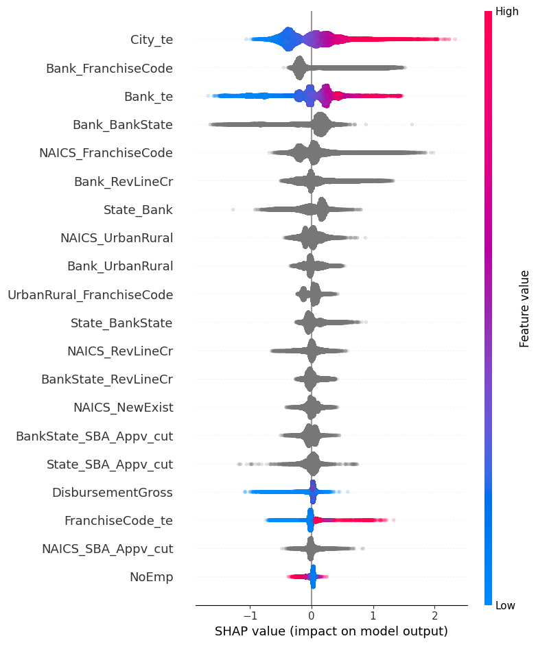

```python
examine_all_reason_codes(test_te, best_model)
```

# Summary plot with Shapley values

SHAP Summary

> SHAP summary plot shows the contribution of the features for each instance (row of data). The sum of the feature contributions and the bias term is equal to the raw prediction of the model, i.e., prediction before applying inverse link function.

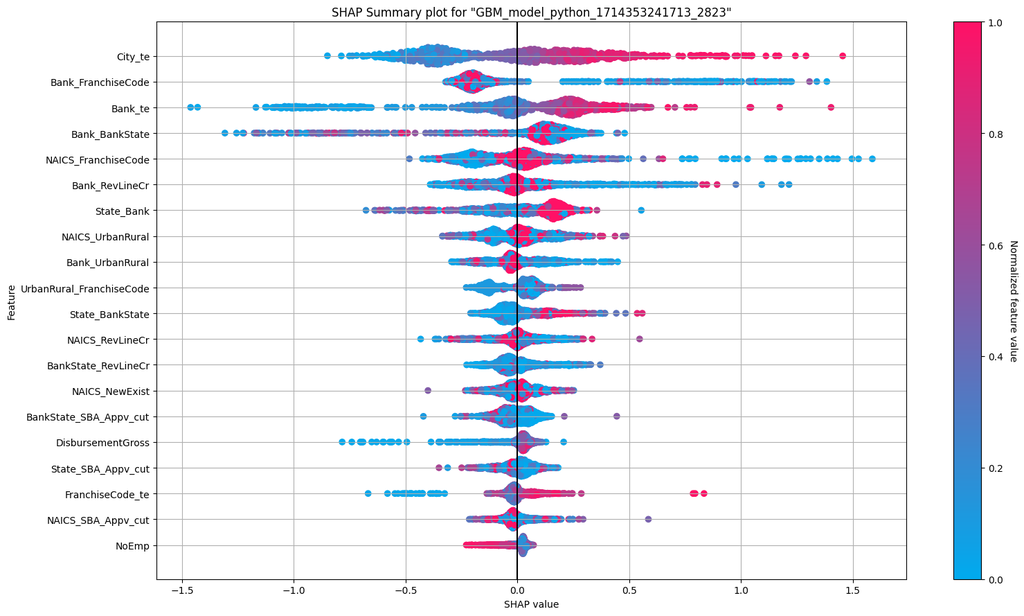

```python
best_model.explain(test_te,include_explanations =['shap_summary']);
```

# Permutation feature importance

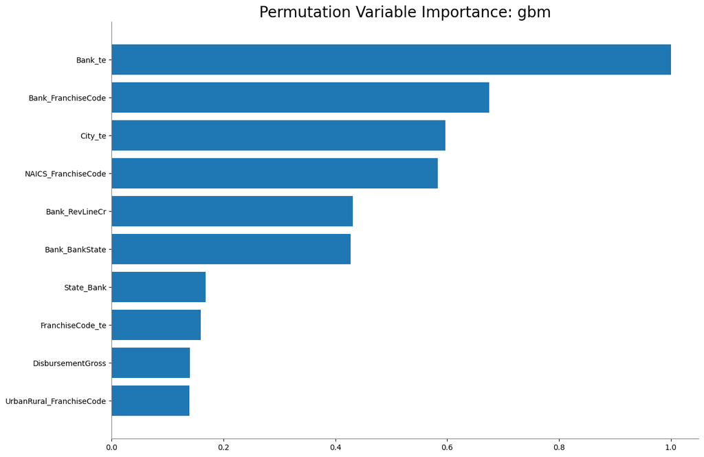

Variable Importances

| Variable | Relative Importance | Scaled Importance | Percentage |
| --- | --- | --- | --- |
| Bank_te | 0.0284783 | 1.0 | 0.1864774 |
| Bank_FranchiseCode | 0.0192211 | 0.6749392 | 0.1258609 |
| City_te | 0.0169819 | 0.5963100 | 0.1111984 |
| NAICS_FranchiseCode | 0.0166022 | 0.5829771 | 0.1087121 |
| Bank_RevLineCr | 0.0122859 | 0.4314117 | 0.0804486 |
| Bank_BankState | 0.0121552 | 0.4268239 | 0.0795930 |
| State_Bank | 0.0047715 | 0.1675488 | 0.0312441 |
| FranchiseCode_te | 0.0045317 | 0.1591295 | 0.0296741 |
| DisbursementGross | 0.0039888 | 0.1400627 | 0.0261185 |
| UrbanRural_FranchiseCode | 0.0039447 | 0.1385150 | 0.0258299 |
| --- | --- | --- | --- |
| BankState_BalanceGross_cut | 0.0 | 0.0 | 0.0 |
| BalanceGross_cut_SBA_Appv_cut | 0.0 | 0.0 | 0.0 |
| NewExist_BalanceGross_cut | 0.0 | 0.0 | 0.0 |
| BalanceGross_cut | 0.0 | 0.0 | 0.0 |
| UrbanRural_BalanceGross_cut | 0.0 | 0.0 | 0.0 |
| RevLineCr_LowDoc | 0.0 | 0.0 | 0.0 |
| BalanceGross | 0.0 | 0.0 | 0.0 |
| RetainedJob_cut_SBA_Appv_cut | 0.0 | 0.0 | 0.0 |
| RetainedJob_cut_LowDoc | 0.0 | 0.0 | 0.0 |
| NewExist_LowDoc | 0.0 | 0.0 | 0.0 |

```
[87 rows x 4 columns]
```

```python
best_model.permutation_importance_plot(test_te)
```

# What are the most important features, how they impact model predictions.

According to the Summary plot with Shapley values(or Shap summary), City_te, Bank_FranchiseCode, Bank_te are the most important features in that order. According to the Permutation feature importance graph, Bank_te, Bank_FranchiseCode, City_te are the most important features in that order.

Features affect the model prediction of 'MIS_status' by their shap values. For example, According to the Shap summary, the higher the 'City_te', the higher the shap value. In other words, Higher 'City_te' value has an influence in the direction of predicting that 'MIS_status' is 1.

# Indivisual observations analysis using Shapley values.

```python
test_te["MIS_Status"].head(20)
```

| MIS_Status |
| --- |
| 0 |
| 1 |
| 0 |
| 0 |
| 0 |
| 1 |
| 0 |
| 0 |
| 0 |
| 0 |
| 0 |
| 0 |
| 0 |
| 0 |
| 1 |
| 0 |
| 0 |
| 0 |
| 0 |
| 1 |

```
[20 rows x 1 column]
```

```python
best_model.predict(test_te).head(20)
```

```
gbm prediction progress: |███████████████████████████████████████████████████████| (done) 100%
```

| predict | p0 | p1 |
| --- | --- | --- |
| 0 | 0.979175 | 0.0208253 |
| 0 | 0.952072 | 0.0479278 |
| 1 | 0.581554 | 0.418446 |
| 0 | 0.896618 | 0.103382 |
| 0 | 0.912671 | 0.0873286 |
| 0 | 0.906274 | 0.0937263 |
| 0 | 0.959727 | 0.0402734 |
| 1 | 0.66142 | 0.33858 |
| 0 | 0.96091 | 0.0390896 |
| 0 | 0.897612 | 0.102388 |
| 0 | 0.993964 | 0.00603563 |
| 1 | 0.573491 | 0.426509 |
| 0 | 0.986225 | 0.0137746 |
| 1 | 0.527061 | 0.472939 |
| 1 | 0.234944 | 0.765056 |
| 0 | 0.971343 | 0.0286574 |
| 0 | 0.973032 | 0.0269675 |
| 0 | 0.981235 | 0.018765 |
| 0 | 0.84971 | 0.15029 |
| 1 | 0.595205 | 0.404795 |

```
[20 rows x 3 columns]
```

Compare the 'MIS_Status' value of the test data and the predicted value obtained by inserting the test data into best_model, and check the correctly predicted observations(row) and incorrectly predicted observations(row) for Individual observations analysis using Shapley values.

```python
# The function is to calculate Shapley values (contributions) and plot them for single record
def examine_indiv_reason_codes(record, model, use_matplotlib=True):

    shap_contribs = model.predict_contributions(record)

    col_mapping = {}
    for i in record.col_names:
        related_cols = [x for x in shap_contribs.col_names if "{}.".format(i) in x]
        if len(related_cols) > 0:
            col_mapping[i] = related_cols

    for k, v in col_mapping.items():
        if len(v) > 1:
            shap_contribs[k] = shap_contribs[v].sum(axis=1,return_frame=True)
            shap_contribs = shap_contribs.drop(v)

    shap_cols = [i for i in shap_contribs.col_names if i != "BiasTerm"]
    bias_term = shap_contribs.as_data_frame()["BiasTerm"].values
    X = record.as_data_frame(use_pandas=True)
    shap_contribs = shap_contribs.as_data_frame(use_pandas=True)

    return shap.force_plot(bias_term,
                           shap_contribs[shap_cols].values,
                           X[shap_cols].values,
                           shap_cols,
                           link="logit",
                           matplotlib=use_matplotlib
                          )
```

```python
shap.initjs()
```

Label 0 is correctly identified

```python
examine_indiv_reason_codes(test_te[0, :], best_model, use_matplotlib=False)
```

```
contributions progress: |████████████████████████████████████████████████████████| (done) 100%
```

```
converting H2O frame to pandas dataframe using single-thread.  For faster conversion using multi-thread, install datatable (for Python 3.9 or lower), or polars and pyarrow (for Python 3.10 or above).
converting H2O frame to pandas dataframe using single-thread.  For faster conversion using multi-thread, install datatable (for Python 3.9 or lower), or polars and pyarrow (for Python 3.10 or above).
converting H2O frame to pandas dataframe using single-thread.  For faster conversion using multi-thread, install datatable (for Python 3.9 or lower), or polars and pyarrow (for Python 3.10 or above).
```

**Visualization omitted, Javascript library not loaded!**  
Have you run `initjs()` in this notebook? If this notebook was from another user you must also trust this notebook (File -> Trust notebook). If you are viewing this notebook on github the Javascript has been stripped for security. If you are using JupyterLab this error is because a JupyterLab extension has not yet been written.

The p1 value of row0 observation is 0.02. 'State_Bank' has the most impact in the direction of predicting that 'MIS_status' is 1. 'City_te' has the most impact in the direction of predicting that 'MIS_status' is 0.

```python
examine_indiv_reason_codes(test_te[3, :], best_model, use_matplotlib=False)
```

```
contributions progress: |████████████████████████████████████████████████████████| (done) 100%
```

```
converting H2O frame to pandas dataframe using single-thread.  For faster conversion using multi-thread, install datatable (for Python 3.9 or lower), or polars and pyarrow (for Python 3.10 or above).
converting H2O frame to pandas dataframe using single-thread.  For faster conversion using multi-thread, install datatable (for Python 3.9 or lower), or polars and pyarrow (for Python 3.10 or above).
converting H2O frame to pandas dataframe using single-thread.  For faster conversion using multi-thread, install datatable (for Python 3.9 or lower), or polars and pyarrow (for Python 3.10 or above).
```

**Visualization omitted, Javascript library not loaded!**  
Have you run `initjs()` in this notebook? If this notebook was from another user you must also trust this notebook (File -> Trust notebook). If you are viewing this notebook on github the Javascript has been stripped for security. If you are using JupyterLab this error is because a JupyterLab extension has not yet been written.

The p1 value of row3 observation is 0.10. 'City_te' has the most impact in the direction of predicting that 'MIS_status' is 1. 'NAICS_FranchiseCode' has the most impact in the direction of predicting that 'MIS_status' is 0.

Label 0 is identified as 1

```python
examine_indiv_reason_codes(test_te[2, :], best_model, use_matplotlib=False)
```

```
contributions progress: |████████████████████████████████████████████████████████| (done) 100%
```

```
converting H2O frame to pandas dataframe using single-thread.  For faster conversion using multi-thread, install datatable (for Python 3.9 or lower), or polars and pyarrow (for Python 3.10 or above).
converting H2O frame to pandas dataframe using single-thread.  For faster conversion using multi-thread, install datatable (for Python 3.9 or lower), or polars and pyarrow (for Python 3.10 or above).
converting H2O frame to pandas dataframe using single-thread.  For faster conversion using multi-thread, install datatable (for Python 3.9 or lower), or polars and pyarrow (for Python 3.10 or above).
```

**Visualization omitted, Javascript library not loaded!**  
Have you run `initjs()` in this notebook? If this notebook was from another user you must also trust this notebook (File -> Trust notebook). If you are viewing this notebook on github the Javascript has been stripped for security. If you are using JupyterLab this error is because a JupyterLab extension has not yet been written.

The p1 value of row2 observation is 0.42. 'Bank_FranchiseCode' has the most impact in the direction of predicting that 'MIS_status' is 1. 'NAICS_FranchiseCode' has the most impact in the direction of predicting that 'MIS_status' is 0.

```python
examine_indiv_reason_codes(test_te[7, :], best_model, use_matplotlib=False)
```

```
contributions progress: |████████████████████████████████████████████████████████| (done) 100%
```

```
converting H2O frame to pandas dataframe using single-thread.  For faster conversion using multi-thread, install datatable (for Python 3.9 or lower), or polars and pyarrow (for Python 3.10 or above).
converting H2O frame to pandas dataframe using single-thread.  For faster conversion using multi-thread, install datatable (for Python 3.9 or lower), or polars and pyarrow (for Python 3.10 or above).
converting H2O frame to pandas dataframe using single-thread.  For faster conversion using multi-thread, install datatable (for Python 3.9 or lower), or polars and pyarrow (for Python 3.10 or above).
```

**Visualization omitted, Javascript library not loaded!**  
Have you run `initjs()` in this notebook? If this notebook was from another user you must also trust this notebook (File -> Trust notebook). If you are viewing this notebook on github the Javascript has been stripped for security. If you are using JupyterLab this error is because a JupyterLab extension has not yet been written.

The p1 value of row7 observation is 0.34. 'Bank_RevLineCr' has the most impact in the direction of predicting that 'MIS_status' is 1. 'Bank_FranchiseCode' has the most impact in the direction of predicting that 'MIS_status' is 0.

Label 1 is correctly identified

```python
examine_indiv_reason_codes(test_te[14, :], best_model, use_matplotlib=False)
```

```
contributions progress: |████████████████████████████████████████████████████████| (done) 100%
```

```
converting H2O frame to pandas dataframe using single-thread.  For faster conversion using multi-thread, install datatable (for Python 3.9 or lower), or polars and pyarrow (for Python 3.10 or above).
converting H2O frame to pandas dataframe using single-thread.  For faster conversion using multi-thread, install datatable (for Python 3.9 or lower), or polars and pyarrow (for Python 3.10 or above).
converting H2O frame to pandas dataframe using single-thread.  For faster conversion using multi-thread, install datatable (for Python 3.9 or lower), or polars and pyarrow (for Python 3.10 or above).
```

**Visualization omitted, Javascript library not loaded!**  
Have you run `initjs()` in this notebook? If this notebook was from another user you must also trust this notebook (File -> Trust notebook). If you are viewing this notebook on github the Javascript has been stripped for security. If you are using JupyterLab this error is because a JupyterLab extension has not yet been written.

The p1 value of row14 observation is 0.77. 'Bank_FranchiseCode' has the most impact in the direction of predicting that 'MIS_status' is 1. 'BankState_NAICS' has the most impact in the direction of predicting that 'MIS_status' is 0.

```python
examine_indiv_reason_codes(test_te[19, :], best_model, use_matplotlib=False)
```

```
contributions progress: |████████████████████████████████████████████████████████| (done) 100%
```

```
converting H2O frame to pandas dataframe using single-thread.  For faster conversion using multi-thread, install datatable (for Python 3.9 or lower), or polars and pyarrow (for Python 3.10 or above).
converting H2O frame to pandas dataframe using single-thread.  For faster conversion using multi-thread, install datatable (for Python 3.9 or lower), or polars and pyarrow (for Python 3.10 or above).
converting H2O frame to pandas dataframe using single-thread.  For faster conversion using multi-thread, install datatable (for Python 3.9 or lower), or polars and pyarrow (for Python 3.10 or above).
```

**Visualization omitted, Javascript library not loaded!**  
Have you run `initjs()` in this notebook? If this notebook was from another user you must also trust this notebook (File -> Trust notebook). If you are viewing this notebook on github the Javascript has been stripped for security. If you are using JupyterLab this error is because a JupyterLab extension has not yet been written.

The p1 value of row19 observation is 0.40. 'Bank_FranchiseCode' has the most impact in the direction of predicting that 'MIS_status' is 1. 'City_te' has the most impact in the direction of predicting that 'MIS_status' is 0.

Label 1 is identified as 0

```python
examine_indiv_reason_codes(test_te[1, :], best_model, use_matplotlib=False)
```

```
contributions progress: |████████████████████████████████████████████████████████| (done) 100%
```

```
converting H2O frame to pandas dataframe using single-thread.  For faster conversion using multi-thread, install datatable (for Python 3.9 or lower), or polars and pyarrow (for Python 3.10 or above).
converting H2O frame to pandas dataframe using single-thread.  For faster conversion using multi-thread, install datatable (for Python 3.9 or lower), or polars and pyarrow (for Python 3.10 or above).
converting H2O frame to pandas dataframe using single-thread.  For faster conversion using multi-thread, install datatable (for Python 3.9 or lower), or polars and pyarrow (for Python 3.10 or above).
```

**Visualization omitted, Javascript library not loaded!**  
Have you run `initjs()` in this notebook? If this notebook was from another user you must also trust this notebook (File -> Trust notebook). If you are viewing this notebook on github the Javascript has been stripped for security. If you are using JupyterLab this error is because a JupyterLab extension has not yet been written.

The p1 value of row1 observation is 0.05. 'City_te' has the most impact in the direction of predicting that 'MIS_status' is 1. 'NAICS_RevLineCr' has the most impact in the direction of predicting that 'MIS_status' is 0.

```python
examine_indiv_reason_codes(test_te[5, :], best_model, use_matplotlib=False)
```

```
contributions progress: |████████████████████████████████████████████████████████| (done) 100%
```

```
converting H2O frame to pandas dataframe using single-thread.  For faster conversion using multi-thread, install datatable (for Python 3.9 or lower), or polars and pyarrow (for Python 3.10 or above).
converting H2O frame to pandas dataframe using single-thread.  For faster conversion using multi-thread, install datatable (for Python 3.9 or lower), or polars and pyarrow (for Python 3.10 or above).
converting H2O frame to pandas dataframe using single-thread.  For faster conversion using multi-thread, install datatable (for Python 3.9 or lower), or polars and pyarrow (for Python 3.10 or above).
```

**Visualization omitted, Javascript library not loaded!**  
Have you run `initjs()` in this notebook? If this notebook was from another user you must also trust this notebook (File -> Trust notebook). If you are viewing this notebook on github the Javascript has been stripped for security. If you are using JupyterLab this error is because a JupyterLab extension has not yet been written.

The p1 value of row5 observation is 0.09. 'Bank_te' has the most impact in the direction of predicting that 'MIS_status' is 1. 'City_te' has the most impact in the direction of predicting that 'MIS_status' is 0.

# Residuals analysis identify and report common patterns

# in the errors made by the model

```python
predict_MIS = best_model.predict(test_te)["predict"]
predict_MIS.columns = ["predict_MIS"]
test_te_p = test_te.cbind(predict_MIS)
test_te_p[["MIS_Status", "predict_MIS"]] = test_te_p[["MIS_Status", "predict_MIS"]].asnumeric()
abs_error = abs(test_te_p["MIS_Status"] - test_te_p["predict_MIS"])

abs_error.columns = ["abs_error"]
test_te_p_abs = test_te_p.cbind(abs_error)
```

```
gbm prediction progress: |███████████████████████████████████████████████████████| (done) 100%
```

```python
test_te_p_abs.head(1)
```

| City_te | State_te | Bank_te | BankState_te | FranchiseCode_te | RevLineCr_te | LowDoc_te | City | State | Bank | BankState | FranchiseCode | RevLineCr | LowDoc | index | Zip | NAICS | NoEmp | NewExist | CreateJob | RetainedJob | UrbanRural | DisbursementGross | BalanceGross | GrAppv | SBA_Appv | RetainedJob_cut | BalanceGross_cut | SBA_Appv_cut | State_Bank | … |
| --- | --- | --- | --- | --- | --- | --- | --- | --- | --- | --- | --- | --- | --- | --- | --- | --- | --- | --- | --- | --- | --- | --- | --- | --- | --- | --- | --- | --- | --- | --- |
| 0.109508 | 0.111624 | 0.121426 | 0.0812697 | 0.127763 | 0.150262 | 0.0950888 | WRANGELL | AK | FIRST BANK | AK | 1 | N | Y | 3 | 99929 | 446110 | 3 | 2 | 0 | 0 | 0 | 75000 | 0 | 75000 | 67500 | RetainedJob_0 | BalanceGross_0 | SBA_Appv_1 | other | … |

```
[1 row x 98 columns]
```

```python
test_te_p_abs_sort = test_te_p_abs.sort(["abs_error"])
```

```python
response = "abs_error"
predictors_gbm = test_te_p_abs_sort.columns
predictors_gbm.remove(response)
predictors_gbm.remove("MIS_Status")
predictors_gbm.remove("predict_MIS")
predictors_gbm.remove("index")
```

```python
res_model = H2OGradientBoostingEstimator(nfolds=best_nfolds,
                                         ntrees=best_ntrees,
                                         max_depth = max_depth,
                                         stopping_rounds=best_stopping_rounds,
                                         stopping_metric='MAE',
                                         seed=1234,
                                         keep_cross_validation_predictions = False)
res_model.train(x=predictors_gbm, y=response, training_frame=test_te_p_abs_sort)
```

```
gbm Model Build progress: |██████████████████████████████████████████████████████| (done) 100%
```

```
Model Details
=============
H2OGradientBoostingEstimator : Gradient Boosting Machine
Model Key: GBM_model_python_1714353241713_12885
```

Model Summary:

|  | number_of_trees | number_of_internal_trees | model_size_in_bytes | min_depth | max_depth | mean_depth | min_leaves | max_leaves | mean_leaves |
| --- | --- | --- | --- | --- | --- | --- | --- | --- | --- |
|  | 130.0 | 130.0 | 175900.0 | 5.0 | 5.0 | 5.0 | 22.0 | 32.0 | 30.723078 |

```
ModelMetricsRegression: gbm
** Reported on train data. **

MSE: 0.08730088487242944
RMSE: 0.2954672314698018
MAE: 0.2030319585492246
RMSLE: 0.20606227138792627
Mean Residual Deviance: 0.08730088487242944
```

```
ModelMetricsRegression: gbm
** Reported on cross-validation data. **

MSE: 0.1223206358500482
RMSE: 0.3497436716368835
MAE: 0.24192716919818685
RMSLE: 0.24607900200183777
Mean Residual Deviance: 0.1223206358500482
```

Cross-Validation Metrics Summary:

|  | mean | sd | cv_1_valid | cv_2_valid | cv_3_valid |
| --- | --- | --- | --- | --- | --- |
| mae | 0.2419228 | 0.0007219 | 0.2425398 | 0.2411289 | 0.2420997 |
| mean_residual_deviance | 0.1223159 | 0.0007594 | 0.1230415 | 0.1215267 | 0.1223795 |
| mse | 0.1223159 | 0.0007594 | 0.1230415 | 0.1215267 | 0.1223795 |
| r2 | 0.1751850 | 0.0021526 | 0.1730136 | 0.1773184 | 0.1752231 |
| residual_deviance | 0.1223159 | 0.0007594 | 0.1230415 | 0.1215267 | 0.1223795 |
| rmse | 0.3497358 | 0.0010859 | 0.3507727 | 0.3486068 | 0.3498279 |
| rmsle | 0.2460746 | 0.0006137 | 0.2467145 | 0.2454908 | 0.2460186 |

Scoring History:

|  | timestamp | duration | number_of_trees | training_rmse | training_mae | training_deviance |
| --- | --- | --- | --- | --- | --- | --- |
|  | 2024-04-28 22:19:37 | 27.388 sec | 0.0 | 0.3850945 | 0.2965956 | 0.1482978 |
|  | 2024-04-28 22:19:37 | 27.474 sec | 1.0 | 0.3791827 | 0.2918395 | 0.1437795 |
|  | 2024-04-28 22:19:37 | 27.536 sec | 2.0 | 0.3739977 | 0.2873904 | 0.1398743 |
|  | 2024-04-28 22:19:37 | 27.594 sec | 3.0 | 0.3695775 | 0.2833019 | 0.1365876 |
|  | 2024-04-28 22:19:37 | 27.652 sec | 4.0 | 0.3657425 | 0.2795468 | 0.1337676 |
|  | 2024-04-28 22:19:37 | 27.709 sec | 5.0 | 0.3624543 | 0.2761083 | 0.1313731 |
|  | 2024-04-28 22:19:37 | 27.767 sec | 6.0 | 0.3595890 | 0.2729529 | 0.1293043 |
|  | 2024-04-28 22:19:37 | 27.824 sec | 7.0 | 0.3566522 | 0.2697047 | 0.1272008 |
|  | 2024-04-28 22:19:37 | 27.895 sec | 8.0 | 0.3542547 | 0.2668747 | 0.1254964 |
|  | 2024-04-28 22:19:37 | 27.958 sec | 9.0 | 0.3522416 | 0.2643809 | 0.1240741 |
| --- | --- | --- | --- | --- | --- | --- |
|  | 2024-04-28 22:19:40 | 30.938 sec | 58.0 | 0.3173201 | 0.2213509 | 0.1006920 |
|  | 2024-04-28 22:19:40 | 30.995 sec | 59.0 | 0.3168681 | 0.2209577 | 0.1004054 |
|  | 2024-04-28 22:19:40 | 31.051 sec | 60.0 | 0.3163780 | 0.2205496 | 0.1000950 |
|  | 2024-04-28 22:19:40 | 31.106 sec | 61.0 | 0.3161196 | 0.2203247 | 0.0999316 |
|  | 2024-04-28 22:19:40 | 31.159 sec | 62.0 | 0.3157734 | 0.2200161 | 0.0997128 |
|  | 2024-04-28 22:19:40 | 31.222 sec | 63.0 | 0.3152301 | 0.2195304 | 0.0993700 |
|  | 2024-04-28 22:19:40 | 31.276 sec | 64.0 | 0.3149679 | 0.2192934 | 0.0992048 |
|  | 2024-04-28 22:19:40 | 31.332 sec | 65.0 | 0.3145582 | 0.2189551 | 0.0989469 |
|  | 2024-04-28 22:19:41 | 31.386 sec | 66.0 | 0.3143027 | 0.2187589 | 0.0987862 |
|  | 2024-04-28 22:19:44 | 34.493 sec | 130.0 | 0.2954672 | 0.2030320 | 0.0873009 |

```
[68 rows x 7 columns]
```

Variable Importances:

| variable | relative_importance | scaled_importance | percentage |
| --- | --- | --- | --- |
| Bank_FranchiseCode | 6952.7011719 | 1.0 | 0.1357536 |
| NAICS_FranchiseCode | 3892.1289062 | 0.5598010 | 0.0759950 |
| State_Bank | 3685.3530273 | 0.5300606 | 0.0719577 |
| State_SBA_Appv_cut | 3656.4809570 | 0.5259080 | 0.0713939 |
| NAICS_UrbanRural | 3463.7934570 | 0.4981939 | 0.0676316 |
| NAICS_NewExist | 2738.8505859 | 0.3939261 | 0.0534769 |
| NAICS_RevLineCr | 2468.5207520 | 0.3550449 | 0.0481986 |
| State_BankState | 2378.6149902 | 0.3421138 | 0.0464432 |
| Bank_RevLineCr | 2177.3486328 | 0.3131659 | 0.0425134 |
| Bank_te | 2018.9973145 | 0.2903903 | 0.0394215 |
| --- | --- | --- | --- |
| UrbanRural_RevLineCr | 0.0 | 0.0 | 0.0 |
| UrbanRural_LowDoc | 0.0 | 0.0 | 0.0 |
| UrbanRural_BalanceGross_cut | 0.0 | 0.0 | 0.0 |
| RevLineCr_LowDoc | 0.0 | 0.0 | 0.0 |
| RevLineCr_BalanceGross_cut | 0.0 | 0.0 | 0.0 |
| LowDoc_FranchiseCode | 0.0 | 0.0 | 0.0 |
| LowDoc_BalanceGross_cut | 0.0 | 0.0 | 0.0 |
| LowDoc_SBA_Appv_cut | 0.0 | 0.0 | 0.0 |
| FranchiseCode_BalanceGross_cut | 0.0 | 0.0 | 0.0 |
| BalanceGross_cut_SBA_Appv_cut | 0.0 | 0.0 | 0.0 |

```
[93 rows x 4 columns]
```

```
[tips]
Use `model.explain()` to inspect the model.
--
Use `h2o.display.toggle_user_tips()` to switch on/off this section.
```

```
contributions progress: |████████████████████████████████████████████████████████| (done) 100%
```

```
converting H2O frame to pandas dataframe using single-thread.  For faster conversion using multi-thread, install datatable (for Python 3.9 or lower), or polars and pyarrow (for Python 3.10 or above).
converting H2O frame to pandas dataframe using single-thread.  For faster conversion using multi-thread, install datatable (for Python 3.9 or lower), or polars and pyarrow (for Python 3.10 or above).
converting H2O frame to pandas dataframe using single-thread.  For faster conversion using multi-thread, install datatable (for Python 3.9 or lower), or polars and pyarrow (for Python 3.10 or above).
```

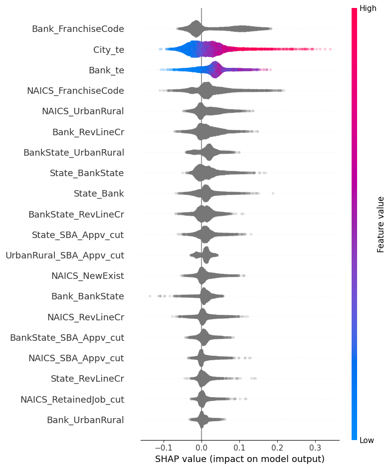

```python
examine_all_reason_codes(test_te_p_abs_sort.tail(10000),res_model)
```

SHAP Summary

> SHAP summary plot shows the contribution of the features for each instance (row of data). The sum of the feature contributions and the bias term is equal to the raw prediction of the model, i.e., prediction before applying inverse link function.

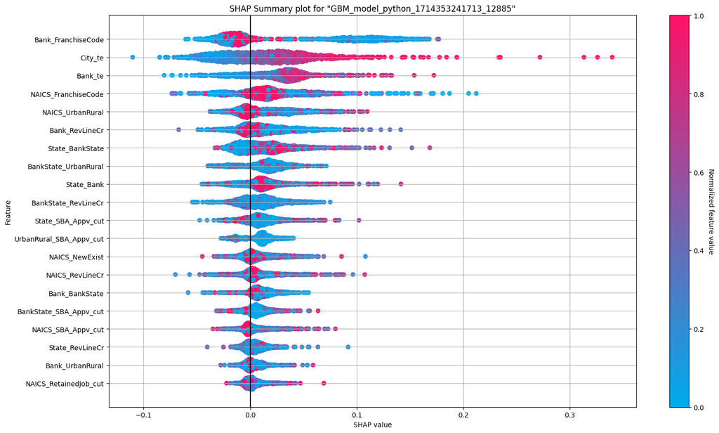

```python
res_model.explain(test_te_p_abs_sort.tail(10000),include_explanations =['shap_summary']);
```

According to the residuals analysis, abs_error(absolute value of the difference between 'MIS_Status' value and predicted value) made by the model shows patterns like above Shap summary. In other words, Bank_FranchiseCode, City_te, Bank_te have the greatest influence on the occurrence of abs_error in that order.

# Save GBM(H2O) model path

```python
model_path = h2o.save_model(model=best_model, path="./artifacts", force=True)
```

```python
model_path
```

```
'C:\\Users\\wizdo\\Downloads\\artifacts\\GBM_model_python_1714353241713_2823'
```

# Summary and Conclusion

In this project, I created and verified a model that predicts MIS_Status values using SBA_loan data. Let me explain in order. First, I loaded the data and checked the characteristics of the data, such as the type of features and missing values. And the missing values were filled with 0 or 'Missing'. Next, the dataset was divided into train, valid, and test in a 6:2:2 ratio. And as a preliminary work of feature engineering, some variables were changed to categorical variables. After that I added engineered features. Additionally, 7 variables were converted through target encoding and this target encoder was saved for the scoring funct value.

Next, I removed the index and did model training and tuning. In this process, the most appropriate parameters were found and the best model was determined. As a result of 60 combinations, the auc value of the valid data was the highest(0.82607) under the condition (nfolds = 3, ntrees = 130, max_depth = 5, stopping_rounds = 3, stopping_metric = MAE), so this model was set as the best model.

By inserting the test dataset into this best model, I obtained the auc value(auc: 0.82316), the threshold value that maximize f1(threshold = 0.23895), and the confusion matrix.

Likewise, I drew a Shap plot, Shap summary, and permutation feature importance graph using this best model and test dataset. Through this, the most important features(City_te, Bank_FranchiseCode, Bank_te) and the direction of their influence were identified. In addition, eight sample graphs were drawn to illustrate how much each feature affected the prediction when the the predicted value of each row matched MIS_Status value or not.

Next, I analyzed the residuals (the absolute value of the difference between MIS_Status and the predicted value) resulting from this model. As a result, I drew a Shap plot and Shap Summary graph and identified the features(Bank_FranchiseCode, City_te, Bank_te) that most affect these errors.

Finally, the best_model was saved for the scoring function and the storage location was checked.